**Mauricio Montero**

← Back to Portfolio Featured Projects Archive CV Contact

[figure not shown]

# Modelos de Regresión con Python

**Tabla de Contenidos del Curso**

**Conceptos Introductorios**

- Machine Learning
- Aprendizaje Supervisado
- Casos de AplicaciÃ³n
- Conceptos Básicos de Regresión: Target, Features
- CorrelaciÃ³n-Falta
- Cross Validation

**AnÃ¡lisis Exploratorio de Datos**

- LibrerÃa Pandas
- Libreria Matplotlib
- ExploraciÃ³n de las propiedades del dataset: shape, data, columns, describe, info
- Creación de gráficos de exploración(Pandas, Matplotlib): plots, pie charts, bar charts, histograms

**Creación de un Modelo de Regresión Lineal**

- LibrerÃa Scikit Learn
- LibrerÃa Numpy
- Importación de los datos, exploración
- SelecciÃ³n de variables Target y features
- DivisiÃ³n en Trainning & Testing
- CreaciÃ³n y Entrenamiento del modelo
- EvaluaciÃ³n del Modelo: R2, REMS, coeficientes y formula
- Predicciones con el modelo
- Cross Validation

### Ejercicios

- RegresiÃ³n Lineal Simple: Pacientes-Presion<-Edad
- Regresión Lineal Múltiple usando Trainning y Testing: Pacientes-Presion<-Edad, Peso
- Regresión Lineal Múltiple utilizando Cross Validation: Autos-hwy_mpg<-city_mpg

**Regularizar Modelo de RegresiÃ³n**

- Lasso
- Ridge

**Mediciones del modelo**

- Hyperparameters
- GridSearchCV

# Introducción a ML

**Machine Learning**: Brinda la capacidad a las computadoras a tomar decisiones con base en los datos.

#### Aprendizaje Supervisado

**Definición**: Permite realizar predicciones basado en los datos históricos de la organización. En este caso a diferencia del aprendizaje no supervisado se cuentan con ejemplos que permiten identificar el comportamiento de los datos. Se compone de dos variables:

- **Target Variable**: Es la variable que desea ser predecida. TambiÃ©n son conocidas como las variables **dependientes**
- **Predictor Variables**: Corresponde al conjunto de variables que utilizará el modelo para predecir la variable target. También se les conoce como **Features** o **variables independientes**.

**Casos de Usos**

- Automatizar tareas manuales que consumen mucho tiempo. Como por ejemplo la creación de diagnósticos médicos, la clasificación de tumores, imágenes, entre otros.
- Predecir valores de conjuntos de datos desconocidos. Como los precios de viviendas, el costo de automÃ³viles, el precio los alquileresy otro tipo de variables continuos.

# Regresión Lineal

Permite predecir variables continuas. La fórmula para este tipo de regresión es la siguiente.

[figure not shown]

##### Fuente: Geeks for Geeks

Donde:

- Y es la variable dependiente o Target.
- X1, X2, X3, X4, Xn son las variables independientes o Features.
- B0, B1, B2,Bn son los coeficientes que determinan el comportamiento de la funciÃ³n.

# Pandas

Esta librería permite a los usuarios crear las estructuras de datos: **Dataframes, Series, Panel**. Para este curso se utilizarán los **Dataframes** los cuales permiten crear estructuras definidas de datos con columnas definidas, es decir son **tablas** donde es posible almacenar registros de información proveniente de archivos CSV, txt, Excel, json, entre otros.

Algunas funcionalidades que ofrece esta librerÃa son:

- CreaciÃ³n de estructuras de datos.
- Almacenamiento de informaciÃ³n.
- TransformaciÃ³n de los datos.
- Filtrado de datos.
- Análisis de información.
- Crear grÃ¡ficos que permitan visualizar los datos.

[figure not shown]

##### Fuente: Python Pandas

# Ejercicio N.1

En este caso se utilizará el CSV DatosPaciente, el cual contiene información relacionada los pacientes de un centro médico específicamente los siguientes datos:

- Edad
- GÃ©nero
- Peso
- Altura
- PresiÃ³n

### Importación de Datos

```python
#Ejercicio 1
import pandas as pd


#Creamos un dataframe
pacientes= pd.read_csv('DatosPaciente.csv',sep=";")
#Podemos revisar los primeros datos del dataframe
print(pacientes.head())

#Otras opciones de para visualizar los registros
```

```
   Edad  Genero   Peso  Altura  Presion
0    17  Hombre  40.86    1.69      114
1    18   Mujer  54.23    1.72      134
2    19  Hombre  52.32    1.69      124
3    19   Mujer  45.81    1.49      128
4    20  Hombre  52.18    1.87      116
```

### Revisión de los datos

```python
# Verificar el tamaÃ±o del dataframe
print("Dimensiones del DataFrame: ", pacientes.shape)

# Revisar el nombre de las columnas
print("Nombre de las columnas: ", pacientes.columns)

# Revisar el tipo de dato de cada columna
print("Tipo de dato de cada columna: ")
print(pacientes.dtypes)
```

```
Dimensiones del DataFrame:  (69, 5)
Nombre de las columnas:  Index(['Edad', 'Genero', 'Peso', 'Altura', 'Presion'], dtype='object')
Tipo de dato de cada columna:
Edad         int64
Genero      object
Peso       float64
Altura     float64
Presion      int64
dtype: object
```

```python
#Podemos revisar datos estadÃsticos bÃ¡sicos de los datos
pacientes.describe()
```

|  | Edad | Peso | Altura | Presion |
| --- | --- | --- | --- | --- |
| count | 69.000000 | 69.000000 | 69.000000 | 69.000000 |
| mean | 46.130435 | 80.295652 | 1.680290 | 148.724638 |
| std | 15.083018 | 18.550104 | 0.137797 | 18.475647 |
| min | 17.000000 | 40.860000 | 1.400000 | 110.000000 |
| 25% | 36.000000 | 66.280000 | 1.600000 | 135.000000 |
| 50% | 47.000000 | 82.330000 | 1.680000 | 149.000000 |
| 75% | 59.000000 | 93.540000 | 1.790000 | 162.000000 |
| max | 70.000000 | 114.070000 | 1.910000 | 185.000000 |

```python
#Obtener datos de una columna
pacientes.info()
```

```
<class 'pandas.core.frame.DataFrame'>
RangeIndex: 69 entries, 0 to 68
Data columns (total 5 columns):
 #   Column   Non-Null Count  Dtype
---  ------   --------------  -----
 0   Edad     69 non-null     int64
 1   Genero   69 non-null     object
 2   Peso     69 non-null     float64
 3   Altura   69 non-null     float64
 4   Presion  69 non-null     int64
dtypes: float64(2), int64(2), object(1)
memory usage: 2.8+ KB
```

### Visualización de datos

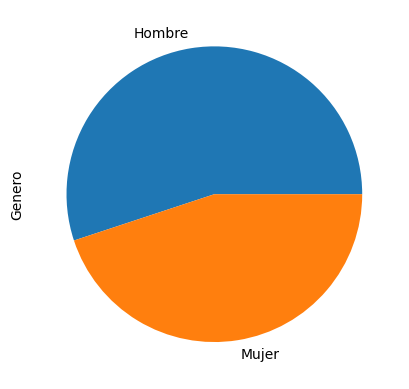

```python
#Con este grÃ¡fico se pueden ver la proporciÃ³n de datos segÃºn el gÃ©nero

pacientes['Genero'].value_counts().plot.pie()
```

### Otras maneras de visualizar los datos

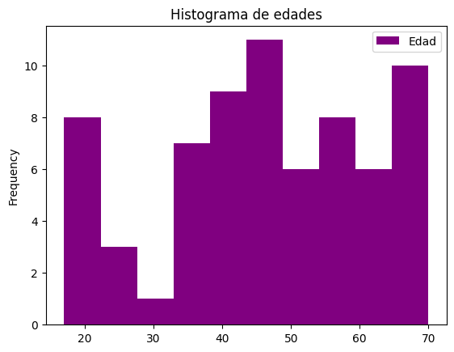

```python
#Histograma segÃºn la edad de los pacientes

pacientes["Edad"].plot(kind="hist", legend=True, title = "Histograma de edades",color="purple")
```

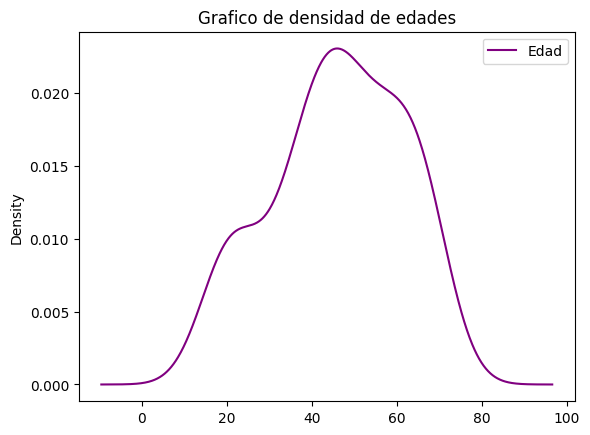

```python
## Grafico Densidad

pacientes["Edad"].plot(kind="density", legend=True, title = "Grafico de densidad de edades",color="purple")
```

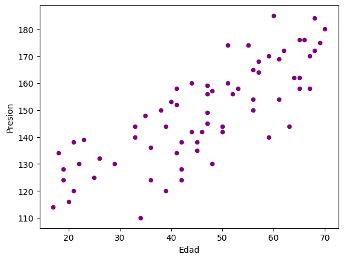

```python
# En este grÃ¡fico se puede el comportamiento de las variables Edad y Presion.
# Posteriormente estas serÃ¡n las variables que utilizaremos para crear nuestro primer modelo de regresiÃ³n lineal.

pacientes.plot(x="Edad",y="Presion",kind="scatter",color="purple")
```